# DSCI 100 - Introduction to Data Science

## Lecture 12 - Bootstrapping & wrap-up

[figure not shown]

# Outline for today

- Few admin notes (Reminders)
- Brief recap of last class followed by today's content: Inference
- Iclicker questions
- Course wrap up + worksheet time

# Housekeeping

- Today is the last lecture (content wise)
- This Thursday: no tutorial assignment, use this class to finish this week’s worksheet and last week’s tutorial (both due on Saturday, April 4)
- Next Tuesday in class (optional): course content recap, review for the final exam, office hours
- Final exam: Thursday, Apr 23, 3:30 pm (Location: IRC 1)
- Course evaluation is live (SEI Surveys)!
  - Canvas > Course Evaluation

## Review

**Inference:** Using a sample to make a conclusion about the wider population

What do the following terms mean:

- population (and population parameter)
- sample
- estimation (and estimate)
- sampling distribution

## Review - Population

Population distribution of price per night for all Airbnb listings in Vancouver.

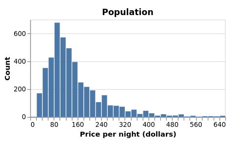

## Review - Sample

Distribution of price per night for a sample of 40 Airbnb listings

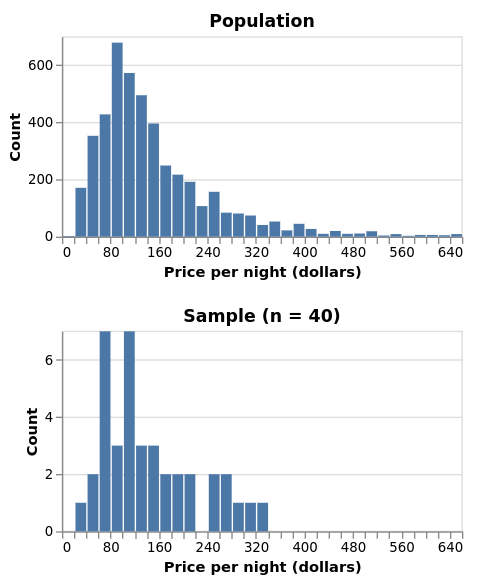

## Review - Sampling distribution

Sampling distribution of the sample means for 20,000 samples of size 40.

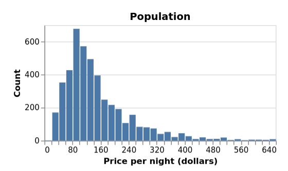

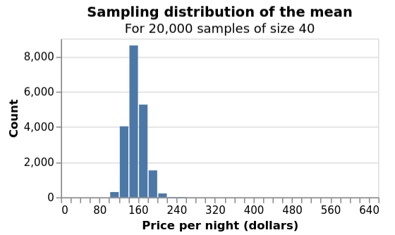

1. What happens to the peak and the range of the histogram if I make my sample smaller / larger?
2. Can we create this figure in a real data analysis problem? Why/Why not?
3. What problem does that cause and what could be some possible resolutions?

## Bootstrapping

We only have one sample... but if it's big enough, the sample looks like the population!

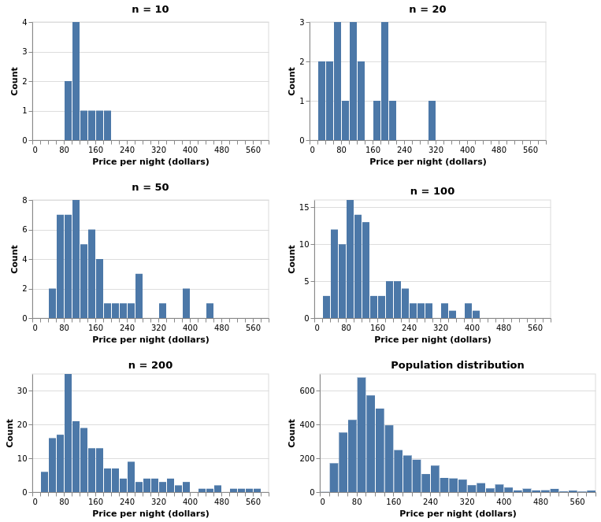

## Generating a single bootstrap sample

1. Randomly draw an observation from the original sample (which was drawn from the population)
2. Record the observation's value
3. Return the observation to the original sample
4. Repeat the above the **same number of times as there are observations in the original sample**

## Bootstrap Sampling Distribution

[figure not shown]

## Sampling vs bootstrap distribution

The bootstrap mean will be centered around the mean of the intial sample rather than the true population mean (which is unknown)

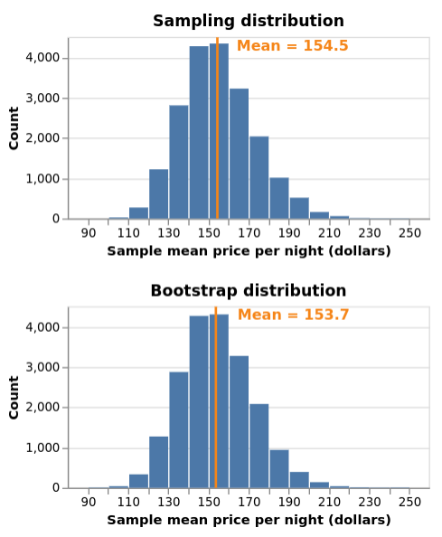

## Using the bootstrap to calculate a plausible range of the mean

1. Take a bootstrap sample
2. Calculate the bootstrap mean (or any other point estimate such as the median, proportion, slope, etc.) from that bootstrap sample
3. Repeat steps (1) and (2) many times to create a **bootstrap sampling distribution** - the distribution of bootstrap point estimates
4. Calculate the plausible range of values around our observed point estimate (we will call this a confidence interval and learn more about it in the worksheet)

## Using the bootstrap to calculate a plausible range of the mean

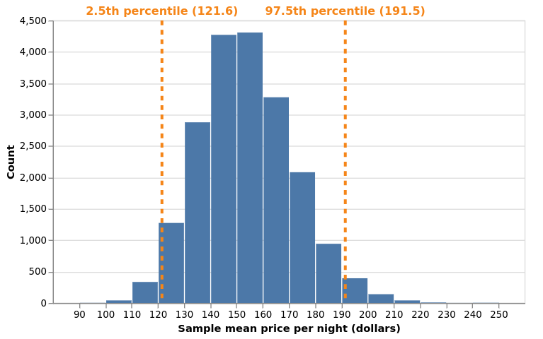

## Data Science wrap-up

At the start of the semester, we started with this gif

[figure not shown]

And we laid out these goals and this path:

## High-level goals of this course:

1. Map research/statistical questions to the appropriate type of data analysis
2. Use modern reproducible tools (Jupyter notebooks, R, tidyverse & tidymodels) to load, wrangle, and explore data; and to solve classification, regression, clustering, and inference problems
3. Correctly interpret and communicate results from all of the above analyses

## Problems we focused on:

1. Predict a class/category for a new observation/measurement (predictive)
2. Predict a value for a new observation/measurement (predictive).
3. Find previously unknown/unlabelled subgroups in your data (exploratory)
4. Estimating a quantity from a population (inferential)

## Where to from here

- you learned a lot in this course!
- many of you are asking for more Data Science (yeah!)
- so here's a list of some UBC courses of interest you might want to take:
  - [STAT 201 - Statistical Inference for Data Science](https://ubc-stat.github.io/stat-201)
  - [STAT 301 - Statistical Modelling for Data Science](https://ubc-stat.github.io/stat-301)
  - [STAT 406 - Methods for Statistical Learning](https://github.com/msalibian/STAT406)
  - [CPSC 330 - Applied Machine Learning](https://courses.students.ubc.ca/cs/courseschedule?tname=subj-course&course=330&campuscd=UBC&dept=CPSC&pname=subjarea)
  - [CPSC 368 - Databases in Data Science](https://courses.students.ubc.ca/cs/courseschedule?pname=subjarea&tname=subj-course&dept=CPSC&course=368)
  - [DSCI 310 - Reproducible and trustworthy workflows for data science](https://ubc-dsci.github.io/dsci-310-student/)
  - [DSCI 320 - Visualization for Data Science](https://courses.students.ubc.ca/cs/courseschedule?pname=subjarea&tname=subj-course&dept=DSCI&course=320)
  - [EOSC 410 - Geoscientific Data Analysis and Empirical Modelling](https://courses.students.ubc.ca/browse-courses/course/COURSE_DEFINITION-3-9254_20240901)

## Minor in Data Science

- UBC also has a new [Minor in Data Science](https://datascience.ubc.ca/minor).
- Anybody can apply -- no matter your home faculty, no matter your major!
- Outside of classes, we can recommend reading
  - [An Introduction to Statistical Learning](https://www.statlearning.com/)
  - [John Hopkins Coursera Data Science courses](https://www.coursera.org/specializations/jhu-data-science)

## Thank-you and it's been a blast!

[figure not shown]

## Course Evaluation

Let's take some time right now to all go do the course evaluation (SEI)!

We really appreciate your feedback here. It helps us understand what worked / what didn't / how to improve!

## One last round of Worksheet work!